# Risk Factor Analysis

## Outcome Variable

**Outcome Variable:** haz

## Predictor Variables

**Intervention Variable:** hdlvry

**Adjustment Set:**

unadjusted

## Stratifying Variables

The analysis was stratified on these variable(s):

- agecat
- studyid
- country

## Data Summary

| agecat | studyid | country | hdlvry | n_cell | n |
| --- | --- | --- | --- | --- | --- |
| Birth | ki1000108-CMC-V-BCS-2002 | INDIA | 0 | 90 | 90 |
| Birth | ki1000108-CMC-V-BCS-2002 | INDIA | 1 | 0 | 90 |
| Birth | ki1000108-IRC | INDIA | 0 | 381 | 388 |
| Birth | ki1000108-IRC | INDIA | 1 | 7 | 388 |
| Birth | ki1000109-EE | PAKISTAN | 0 | 2 | 2 |
| Birth | ki1000109-EE | PAKISTAN | 1 | 0 | 2 |
| Birth | ki1000304b-SAS-CompFeed | INDIA | 0 | 11 | 180 |
| Birth | ki1000304b-SAS-CompFeed | INDIA | 1 | 169 | 180 |
| Birth | ki1017093c-NIH-Crypto | BANGLADESH | 0 | 22 | 27 |
| Birth | ki1017093c-NIH-Crypto | BANGLADESH | 1 | 5 | 27 |
| Birth | ki1135781-COHORTS | INDIA | 0 | 2938 | 4694 |
| Birth | ki1135781-COHORTS | INDIA | 1 | 1756 | 4694 |
| Birth | kiGH5241-JiVitA-3 | BANGLADESH | 0 | 11 | 300 |
| Birth | kiGH5241-JiVitA-3 | BANGLADESH | 1 | 289 | 300 |
| Birth | kiGH5241-JiVitA-4 | BANGLADESH | 0 | 47 | 820 |
| Birth | kiGH5241-JiVitA-4 | BANGLADESH | 1 | 773 | 820 |
| 6 months | ki1000108-CMC-V-BCS-2002 | INDIA | 0 | 358 | 366 |
| 6 months | ki1000108-CMC-V-BCS-2002 | INDIA | 1 | 8 | 366 |
| 6 months | ki1000108-IRC | INDIA | 0 | 399 | 407 |
| 6 months | ki1000108-IRC | INDIA | 1 | 8 | 407 |
| 6 months | ki1000109-EE | PAKISTAN | 0 | 248 | 370 |
| 6 months | ki1000109-EE | PAKISTAN | 1 | 122 | 370 |
| 6 months | ki1000304b-SAS-CompFeed | INDIA | 0 | 147 | 1091 |
| 6 months | ki1000304b-SAS-CompFeed | INDIA | 1 | 944 | 1091 |
| 6 months | ki1000304b-SAS-FoodSuppl | INDIA | 0 | 76 | 380 |
| 6 months | ki1000304b-SAS-FoodSuppl | INDIA | 1 | 304 | 380 |
| 6 months | ki1017093b-PROVIDE | BANGLADESH | 0 | 433 | 583 |
| 6 months | ki1017093b-PROVIDE | BANGLADESH | 1 | 150 | 583 |
| 6 months | ki1017093c-NIH-Crypto | BANGLADESH | 0 | 554 | 715 |
| 6 months | ki1017093c-NIH-Crypto | BANGLADESH | 1 | 161 | 715 |
| 6 months | ki1066203-TanzaniaChild2 | TANZANIA, UNITED REPUBLIC OF | 0 | 1889 | 1921 |
| 6 months | ki1066203-TanzaniaChild2 | TANZANIA, UNITED REPUBLIC OF | 1 | 32 | 1921 |
| 6 months | ki1113344-GMS-Nepal | NEPAL | 0 | 129 | 527 |
| 6 months | ki1113344-GMS-Nepal | NEPAL | 1 | 398 | 527 |
| 6 months | ki1135781-COHORTS | INDIA | 0 | 2900 | 4699 |
| 6 months | ki1135781-COHORTS | INDIA | 1 | 1799 | 4699 |
| 6 months | kiGH5241-JiVitA-3 | BANGLADESH | 0 | 39 | 332 |
| 6 months | kiGH5241-JiVitA-3 | BANGLADESH | 1 | 293 | 332 |
| 6 months | kiGH5241-JiVitA-4 | BANGLADESH | 0 | 1081 | 4038 |
| 6 months | kiGH5241-JiVitA-4 | BANGLADESH | 1 | 2957 | 4038 |
| 24 months | ki1000108-CMC-V-BCS-2002 | INDIA | 0 | 361 | 369 |
| 24 months | ki1000108-CMC-V-BCS-2002 | INDIA | 1 | 8 | 369 |
| 24 months | ki1000108-IRC | INDIA | 0 | 401 | 409 |
| 24 months | ki1000108-IRC | INDIA | 1 | 8 | 409 |
| 24 months | ki1017093b-PROVIDE | BANGLADESH | 0 | 432 | 577 |
| 24 months | ki1017093b-PROVIDE | BANGLADESH | 1 | 145 | 577 |
| 24 months | ki1017093c-NIH-Crypto | BANGLADESH | 0 | 391 | 514 |
| 24 months | ki1017093c-NIH-Crypto | BANGLADESH | 1 | 123 | 514 |
| 24 months | ki1066203-TanzaniaChild2 | TANZANIA, UNITED REPUBLIC OF | 0 | 6 | 6 |
| 24 months | ki1066203-TanzaniaChild2 | TANZANIA, UNITED REPUBLIC OF | 1 | 0 | 6 |
| 24 months | ki1113344-GMS-Nepal | NEPAL | 0 | 120 | 467 |
| 24 months | ki1113344-GMS-Nepal | NEPAL | 1 | 347 | 467 |
| 24 months | ki1135781-COHORTS | INDIA | 0 | 2233 | 3559 |
| 24 months | ki1135781-COHORTS | INDIA | 1 | 1326 | 3559 |
| 24 months | kiGH5241-JiVitA-3 | BANGLADESH | 0 | 35 | 291 |
| 24 months | kiGH5241-JiVitA-3 | BANGLADESH | 1 | 256 | 291 |
| 24 months | kiGH5241-JiVitA-4 | BANGLADESH | 0 | 1033 | 4005 |
| 24 months | kiGH5241-JiVitA-4 | BANGLADESH | 1 | 2972 | 4005 |

The following strata were considered:

- agecat: 24 months, studyid: ki1000108-CMC-V-BCS-2002, country: INDIA
- agecat: 24 months, studyid: ki1000108-IRC, country: INDIA
- agecat: 24 months, studyid: ki1017093b-PROVIDE, country: BANGLADESH
- agecat: 24 months, studyid: ki1017093c-NIH-Crypto, country: BANGLADESH
- agecat: 24 months, studyid: ki1066203-TanzaniaChild2, country: TANZANIA, UNITED REPUBLIC OF
- agecat: 24 months, studyid: ki1113344-GMS-Nepal, country: NEPAL
- agecat: 24 months, studyid: ki1135781-COHORTS, country: INDIA
- agecat: 24 months, studyid: kiGH5241-JiVitA-3, country: BANGLADESH
- agecat: 24 months, studyid: kiGH5241-JiVitA-4, country: BANGLADESH
- agecat: 6 months, studyid: ki1000108-CMC-V-BCS-2002, country: INDIA
- agecat: 6 months, studyid: ki1000108-IRC, country: INDIA
- agecat: 6 months, studyid: ki1000109-EE, country: PAKISTAN
- agecat: 6 months, studyid: ki1000304b-SAS-CompFeed, country: INDIA
- agecat: 6 months, studyid: ki1000304b-SAS-FoodSuppl, country: INDIA
- agecat: 6 months, studyid: ki1017093b-PROVIDE, country: BANGLADESH
- agecat: 6 months, studyid: ki1017093c-NIH-Crypto, country: BANGLADESH
- agecat: 6 months, studyid: ki1066203-TanzaniaChild2, country: TANZANIA, UNITED REPUBLIC OF
- agecat: 6 months, studyid: ki1113344-GMS-Nepal, country: NEPAL
- agecat: 6 months, studyid: ki1135781-COHORTS, country: INDIA
- agecat: 6 months, studyid: kiGH5241-JiVitA-3, country: BANGLADESH
- agecat: 6 months, studyid: kiGH5241-JiVitA-4, country: BANGLADESH
- agecat: Birth, studyid: ki1000108-CMC-V-BCS-2002, country: INDIA
- agecat: Birth, studyid: ki1000108-IRC, country: INDIA
- agecat: Birth, studyid: ki1000109-EE, country: PAKISTAN
- agecat: Birth, studyid: ki1000304b-SAS-CompFeed, country: INDIA
- agecat: Birth, studyid: ki1017093c-NIH-Crypto, country: BANGLADESH
- agecat: Birth, studyid: ki1135781-COHORTS, country: INDIA
- agecat: Birth, studyid: kiGH5241-JiVitA-3, country: BANGLADESH
- agecat: Birth, studyid: kiGH5241-JiVitA-4, country: BANGLADESH

### Dropped Strata

Some strata were dropped due to rare outcomes:

- agecat: Birth, studyid: ki1000108-CMC-V-BCS-2002, country: INDIA
- agecat: Birth, studyid: ki1000109-EE, country: PAKISTAN
- agecat: 24 months, studyid: ki1066203-TanzaniaChild2, country: TANZANIA, UNITED REPUBLIC OF

## Methods Detail

We’re interested in the causal parameters $E[Y_a]$ for all values of $a \in \mathcal{A}$. These parameters represent the mean outcome if, possibly contrary to fact, we intervened to set all units to have $A=a$. Under the randomization and positivity assumptions, these are identified by the statistical parameters $\psi_a=E_W[E_{Y|A,W}(Y|A=a,W)]$. In addition, we’re interested in the mean of $Y$, $E[Y]$ under no intervention (the observed mean). We will estimate these parameters by using SuperLearner to fit the relevant likelihood factors – $E_{Y|A,W}(Y|A=a,W)$ and $p(A=a|W)$, and then updating our likelihood fit using a joint TMLE.

For unadjusted analyses ($W=\{\}$), initial likelihoods were estimated using Lrnr_glm to estimate the simple $E(Y|A)$ and Lrnr_mean to estimate $p(A)$. For adjusted analyses, a small library containing Lrnr_glmnet, Lrnr_xgboost, and Lrnr_mean was used.

Having estimated these parameters, we will then use the delta method to estimate relative risks and attributable risks relative to a prespecified baseline level of $A$.

# Results Detail

## Results Plots

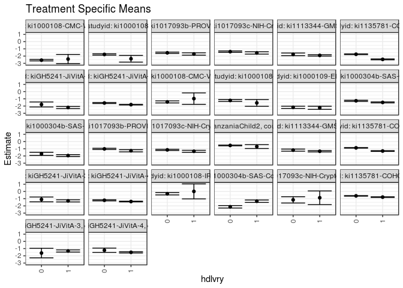

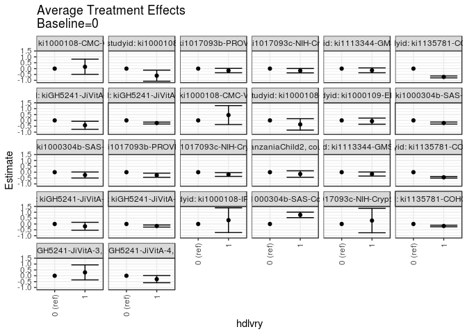

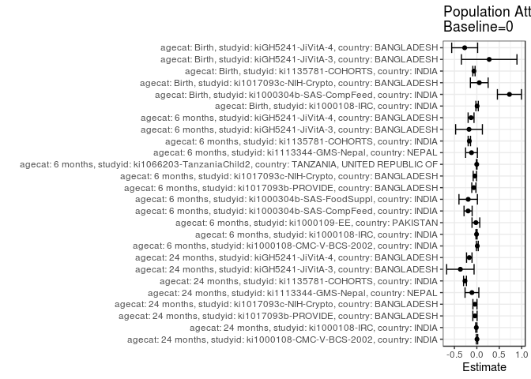

## Results Table

### Parameter: TSM

| agecat | studyid | country | intervention_level | baseline_level | estimate | ci_lower | ci_upper |
| --- | --- | --- | --- | --- | --- | --- | --- |
| Birth | ki1000108-IRC | INDIA | 0 | NA | -0.3138845 | -0.4765233 | -0.1512457 |
| Birth | ki1000108-IRC | INDIA | 1 | NA | 0.0100000 | -1.0310607 | 1.0510607 |
| Birth | ki1000304b-SAS-CompFeed | INDIA | 0 | NA | -2.1245455 | -2.2946461 | -1.9544448 |
| Birth | ki1000304b-SAS-CompFeed | INDIA | 1 | NA | -1.3503550 | -1.5184376 | -1.1822724 |
| Birth | ki1017093c-NIH-Crypto | BANGLADESH | 0 | NA | -1.1640909 | -1.6003506 | -0.7278312 |
| Birth | ki1017093c-NIH-Crypto | BANGLADESH | 1 | NA | -0.8720000 | -1.8180272 | 0.0740272 |
| Birth | ki1135781-COHORTS | INDIA | 0 | NA | -0.6120967 | -0.6545560 | -0.5696373 |
| Birth | ki1135781-COHORTS | INDIA | 1 | NA | -0.7835649 | -0.8357866 | -0.7313433 |
| Birth | kiGH5241-JiVitA-3 | BANGLADESH | 0 | NA | -1.6136364 | -2.2774678 | -0.9498049 |
| Birth | kiGH5241-JiVitA-3 | BANGLADESH | 1 | NA | -1.3276471 | -1.4783139 | -1.1769802 |
| Birth | kiGH5241-JiVitA-4 | BANGLADESH | 0 | NA | -1.2253191 | -1.5212505 | -0.9293878 |
| Birth | kiGH5241-JiVitA-4 | BANGLADESH | 1 | NA | -1.5131695 | -1.6001541 | -1.4261849 |
| 6 months | ki1000108-CMC-V-BCS-2002 | INDIA | 0 | NA | -1.4288687 | -1.5726614 | -1.2850760 |
| 6 months | ki1000108-CMC-V-BCS-2002 | INDIA | 1 | NA | -0.9754167 | -1.7693720 | -0.1814613 |
| 6 months | ki1000108-IRC | INDIA | 0 | NA | -1.2276901 | -1.3618868 | -1.0934933 |
| 6 months | ki1000108-IRC | INDIA | 1 | NA | -1.5693750 | -2.0379505 | -1.1007995 |
| 6 months | ki1000109-EE | PAKISTAN | 0 | NA | -2.1799194 | -2.3311081 | -2.0287306 |
| 6 months | ki1000109-EE | PAKISTAN | 1 | NA | -2.2443443 | -2.4581425 | -2.0305460 |
| 6 months | ki1000304b-SAS-CompFeed | INDIA | 0 | NA | -1.2747619 | -1.3533985 | -1.1961254 |
| 6 months | ki1000304b-SAS-CompFeed | INDIA | 1 | NA | -1.5003549 | -1.5683575 | -1.4323523 |
| 6 months | ki1000304b-SAS-FoodSuppl | INDIA | 0 | NA | -1.7059211 | -1.9277126 | -1.4841295 |
| 6 months | ki1000304b-SAS-FoodSuppl | INDIA | 1 | NA | -1.9468750 | -2.0764992 | -1.8172508 |
| 6 months | ki1017093b-PROVIDE | BANGLADESH | 0 | NA | -1.0202810 | -1.1083121 | -0.9322498 |
| 6 months | ki1017093b-PROVIDE | BANGLADESH | 1 | NA | -1.2800000 | -1.4297621 | -1.1302379 |
| 6 months | ki1017093c-NIH-Crypto | BANGLADESH | 0 | NA | -1.1538899 | -1.2366235 | -1.0711563 |
| 6 months | ki1017093c-NIH-Crypto | BANGLADESH | 1 | NA | -1.3527950 | -1.4899409 | -1.2156492 |
| 6 months | ki1066203-TanzaniaChild2 | TANZANIA, UNITED REPUBLIC OF | 0 | NA | -0.5414554 | -0.5927823 | -0.4901284 |
| 6 months | ki1066203-TanzaniaChild2 | TANZANIA, UNITED REPUBLIC OF | 1 | NA | -0.6976562 | -0.9673928 | -0.4279197 |
| 6 months | ki1113344-GMS-Nepal | NEPAL | 0 | NA | -1.1922739 | -1.3383704 | -1.0461774 |
| 6 months | ki1113344-GMS-Nepal | NEPAL | 1 | NA | -1.3497446 | -1.4437092 | -1.2557800 |
| 6 months | ki1135781-COHORTS | INDIA | 0 | NA | -0.8786897 | -0.9206224 | -0.8367569 |
| 6 months | ki1135781-COHORTS | INDIA | 1 | NA | -1.3152029 | -1.3685317 | -1.2618741 |
| 6 months | kiGH5241-JiVitA-3 | BANGLADESH | 0 | NA | -1.1043590 | -1.4380294 | -0.7706885 |
| 6 months | kiGH5241-JiVitA-3 | BANGLADESH | 1 | NA | -1.3019454 | -1.4524263 | -1.1514645 |
| 6 months | kiGH5241-JiVitA-4 | BANGLADESH | 0 | NA | -1.2194033 | -1.2993889 | -1.1394178 |
| 6 months | kiGH5241-JiVitA-4 | BANGLADESH | 1 | NA | -1.3951894 | -1.4427840 | -1.3475948 |
| 24 months | ki1000108-CMC-V-BCS-2002 | INDIA | 0 | NA | -2.5650139 | -2.6667807 | -2.4632470 |
| 24 months | ki1000108-CMC-V-BCS-2002 | INDIA | 1 | NA | -2.4075000 | -3.0472699 | -1.7677301 |
| 24 months | ki1000108-IRC | INDIA | 0 | NA | -1.7707024 | -1.8661096 | -1.6752952 |
| 24 months | ki1000108-IRC | INDIA | 1 | NA | -2.3727083 | -2.8339592 | -1.9114574 |
| 24 months | ki1017093b-PROVIDE | BANGLADESH | 0 | NA | -1.5444213 | -1.6413034 | -1.4475392 |
| 24 months | ki1017093b-PROVIDE | BANGLADESH | 1 | NA | -1.7103448 | -1.8712209 | -1.5494688 |
| 24 months | ki1017093c-NIH-Crypto | BANGLADESH | 0 | NA | -1.3873657 | -1.4840262 | -1.2907053 |
| 24 months | ki1017093c-NIH-Crypto | BANGLADESH | 1 | NA | -1.5635772 | -1.7243351 | -1.4028194 |
| 24 months | ki1113344-GMS-Nepal | NEPAL | 0 | NA | -1.7593472 | -1.9419117 | -1.5767827 |
| 24 months | ki1113344-GMS-Nepal | NEPAL | 1 | NA | -1.9063881 | -2.0037908 | -1.8089853 |
| 24 months | ki1135781-COHORTS | INDIA | 0 | NA | -1.7458039 | -1.7946360 | -1.6969717 |
| 24 months | ki1135781-COHORTS | INDIA | 1 | NA | -2.4542006 | -2.5173299 | -2.3910713 |
| 24 months | kiGH5241-JiVitA-3 | BANGLADESH | 0 | NA | -1.7877143 | -2.1337599 | -1.4416687 |
| 24 months | kiGH5241-JiVitA-3 | BANGLADESH | 1 | NA | -2.2051172 | -2.3479599 | -2.0622745 |
| 24 months | kiGH5241-JiVitA-4 | BANGLADESH | 0 | NA | -1.5814424 | -1.6537665 | -1.5091183 |
| 24 months | kiGH5241-JiVitA-4 | BANGLADESH | 1 | NA | -1.8086171 | -1.8519938 | -1.7652403 |

### Parameter: E(Y)

| agecat | studyid | country | intervention_level | baseline_level | estimate | ci_lower | ci_upper |
| --- | --- | --- | --- | --- | --- | --- | --- |
| Birth | ki1000108-IRC | INDIA | NA | NA | -0.3080412 | -0.4687931 | -0.1472894 |
| Birth | ki1000304b-SAS-CompFeed | INDIA | NA | NA | -1.3976667 | -1.5639119 | -1.2314214 |
| Birth | ki1017093c-NIH-Crypto | BANGLADESH | NA | NA | -1.1100000 | -1.5086894 | -0.7113106 |
| Birth | ki1135781-COHORTS | INDIA | NA | NA | -0.6762420 | -0.7093108 | -0.6431732 |
| Birth | kiGH5241-JiVitA-3 | BANGLADESH | NA | NA | -1.3381333 | -1.4898513 | -1.1864153 |
| Birth | kiGH5241-JiVitA-4 | BANGLADESH | NA | NA | -1.4966707 | -1.5808284 | -1.4125130 |
| 6 months | ki1000108-CMC-V-BCS-2002 | INDIA | NA | NA | -1.4189572 | -1.5607165 | -1.2771979 |
| 6 months | ki1000108-IRC | INDIA | NA | NA | -1.2344062 | -1.3658524 | -1.1029600 |
| 6 months | ki1000109-EE | PAKISTAN | NA | NA | -2.2011622 | -2.3246467 | -2.0776776 |
| 6 months | ki1000304b-SAS-CompFeed | INDIA | NA | NA | -1.4699588 | -1.5446559 | -1.3952616 |
| 6 months | ki1000304b-SAS-FoodSuppl | INDIA | NA | NA | -1.8986842 | -2.0118892 | -1.7854792 |
| 6 months | ki1017093b-PROVIDE | BANGLADESH | NA | NA | -1.0871041 | -1.1635539 | -1.0106543 |
| 6 months | ki1017093c-NIH-Crypto | BANGLADESH | NA | NA | -1.1986783 | -1.2700937 | -1.1272630 |
| 6 months | ki1066203-TanzaniaChild2 | TANZANIA, UNITED REPUBLIC OF | NA | NA | -0.5440573 | -0.5945614 | -0.4935533 |
| 6 months | ki1113344-GMS-Nepal | NEPAL | NA | NA | -1.3111986 | -1.3908744 | -1.2315228 |
| 6 months | ki1135781-COHORTS | INDIA | NA | NA | -1.0458076 | -1.0793244 | -1.0122908 |
| 6 months | kiGH5241-JiVitA-3 | BANGLADESH | NA | NA | -1.2787349 | -1.4248268 | -1.1326431 |
| 6 months | kiGH5241-JiVitA-4 | BANGLADESH | NA | NA | -1.3481303 | -1.3904710 | -1.3057895 |
| 24 months | ki1000108-CMC-V-BCS-2002 | INDIA | NA | NA | -2.5615989 | -2.6621298 | -2.4610681 |
| 24 months | ki1000108-IRC | INDIA | NA | NA | -1.7824776 | -1.8765600 | -1.6883952 |
| 24 months | ki1017093b-PROVIDE | BANGLADESH | NA | NA | -1.5861179 | -1.6693668 | -1.5028689 |
| 24 months | ki1017093c-NIH-Crypto | BANGLADESH | NA | NA | -1.4295331 | -1.5127726 | -1.3462935 |
| 24 months | ki1113344-GMS-Nepal | NEPAL | NA | NA | -1.8686046 | -1.9550497 | -1.7821594 |
| 24 months | ki1135781-COHORTS | INDIA | NA | NA | -2.0097359 | -2.0499675 | -1.9695043 |
| 24 months | kiGH5241-JiVitA-3 | BANGLADESH | NA | NA | -2.1549141 | -2.2975185 | -2.0123097 |
| 24 months | kiGH5241-JiVitA-4 | BANGLADESH | NA | NA | -1.7500225 | -1.7884190 | -1.7116259 |

### Parameter: ATE

| agecat | studyid | country | intervention_level | baseline_level | estimate | ci_lower | ci_upper |
| --- | --- | --- | --- | --- | --- | --- | --- |
| Birth | ki1000108-IRC | INDIA | 0 | 0 | 0.0000000 | 0.0000000 | 0.0000000 |
| Birth | ki1000108-IRC | INDIA | 1 | 0 | 0.3238845 | -0.7298036 | 1.3775727 |
| Birth | ki1000304b-SAS-CompFeed | INDIA | 0 | 0 | 0.0000000 | 0.0000000 | 0.0000000 |
| Birth | ki1000304b-SAS-CompFeed | INDIA | 1 | 0 | 0.7741904 | 0.5389226 | 1.0094583 |
| Birth | ki1017093c-NIH-Crypto | BANGLADESH | 0 | 0 | 0.0000000 | 0.0000000 | 0.0000000 |
| Birth | ki1017093c-NIH-Crypto | BANGLADESH | 1 | 0 | 0.2920909 | -0.7496816 | 1.3338634 |
| Birth | ki1135781-COHORTS | INDIA | 0 | 0 | 0.0000000 | 0.0000000 | 0.0000000 |
| Birth | ki1135781-COHORTS | INDIA | 1 | 0 | -0.1714683 | -0.2387728 | -0.1041638 |
| Birth | kiGH5241-JiVitA-3 | BANGLADESH | 0 | 0 | 0.0000000 | 0.0000000 | 0.0000000 |
| Birth | kiGH5241-JiVitA-3 | BANGLADESH | 1 | 0 | 0.2859893 | -0.3547740 | 0.9267526 |
| Birth | kiGH5241-JiVitA-4 | BANGLADESH | 0 | 0 | 0.0000000 | 0.0000000 | 0.0000000 |
| Birth | kiGH5241-JiVitA-4 | BANGLADESH | 1 | 0 | -0.2878503 | -0.5950797 | 0.0193790 |
| 6 months | ki1000108-CMC-V-BCS-2002 | INDIA | 0 | 0 | 0.0000000 | 0.0000000 | 0.0000000 |
| 6 months | ki1000108-CMC-V-BCS-2002 | INDIA | 1 | 0 | 0.4534520 | -0.3534193 | 1.2603234 |
| 6 months | ki1000108-IRC | INDIA | 0 | 0 | 0.0000000 | 0.0000000 | 0.0000000 |
| 6 months | ki1000108-IRC | INDIA | 1 | 0 | -0.3416849 | -0.8290982 | 0.1457284 |
| 6 months | ki1000109-EE | PAKISTAN | 0 | 0 | 0.0000000 | 0.0000000 | 0.0000000 |
| 6 months | ki1000109-EE | PAKISTAN | 1 | 0 | -0.0644249 | -0.3262793 | 0.1974295 |
| 6 months | ki1000304b-SAS-CompFeed | INDIA | 0 | 0 | 0.0000000 | 0.0000000 | 0.0000000 |
| 6 months | ki1000304b-SAS-CompFeed | INDIA | 1 | 0 | -0.2255930 | -0.3121919 | -0.1389941 |
| 6 months | ki1000304b-SAS-FoodSuppl | INDIA | 0 | 0 | 0.0000000 | 0.0000000 | 0.0000000 |
| 6 months | ki1000304b-SAS-FoodSuppl | INDIA | 1 | 0 | -0.2409539 | -0.4978467 | 0.0159389 |
| 6 months | ki1017093b-PROVIDE | BANGLADESH | 0 | 0 | 0.0000000 | 0.0000000 | 0.0000000 |
| 6 months | ki1017093b-PROVIDE | BANGLADESH | 1 | 0 | -0.2597190 | -0.4334377 | -0.0860004 |
| 6 months | ki1017093c-NIH-Crypto | BANGLADESH | 0 | 0 | 0.0000000 | 0.0000000 | 0.0000000 |
| 6 months | ki1017093c-NIH-Crypto | BANGLADESH | 1 | 0 | -0.1989051 | -0.3590733 | -0.0387370 |
| 6 months | ki1066203-TanzaniaChild2 | TANZANIA, UNITED REPUBLIC OF | 0 | 0 | 0.0000000 | 0.0000000 | 0.0000000 |
| 6 months | ki1066203-TanzaniaChild2 | TANZANIA, UNITED REPUBLIC OF | 1 | 0 | -0.1562009 | -0.4307774 | 0.1183756 |
| 6 months | ki1113344-GMS-Nepal | NEPAL | 0 | 0 | 0.0000000 | 0.0000000 | 0.0000000 |
| 6 months | ki1113344-GMS-Nepal | NEPAL | 1 | 0 | -0.1574707 | -0.3311759 | 0.0162346 |
| 6 months | ki1135781-COHORTS | INDIA | 0 | 0 | 0.0000000 | 0.0000000 | 0.0000000 |
| 6 months | ki1135781-COHORTS | INDIA | 1 | 0 | -0.4365132 | -0.5043536 | -0.3686729 |
| 6 months | kiGH5241-JiVitA-3 | BANGLADESH | 0 | 0 | 0.0000000 | 0.0000000 | 0.0000000 |
| 6 months | kiGH5241-JiVitA-3 | BANGLADESH | 1 | 0 | -0.1975864 | -0.5355669 | 0.1403941 |
| 6 months | kiGH5241-JiVitA-4 | BANGLADESH | 0 | 0 | 0.0000000 | 0.0000000 | 0.0000000 |
| 6 months | kiGH5241-JiVitA-4 | BANGLADESH | 1 | 0 | -0.1757861 | -0.2656783 | -0.0858938 |
| 24 months | ki1000108-CMC-V-BCS-2002 | INDIA | 0 | 0 | 0.0000000 | 0.0000000 | 0.0000000 |
| 24 months | ki1000108-CMC-V-BCS-2002 | INDIA | 1 | 0 | 0.1575139 | -0.4902994 | 0.8053271 |
| 24 months | ki1000108-IRC | INDIA | 0 | 0 | 0.0000000 | 0.0000000 | 0.0000000 |
| 24 months | ki1000108-IRC | INDIA | 1 | 0 | -0.6020059 | -1.0730207 | -0.1309911 |
| 24 months | ki1017093b-PROVIDE | BANGLADESH | 0 | 0 | 0.0000000 | 0.0000000 | 0.0000000 |
| 24 months | ki1017093b-PROVIDE | BANGLADESH | 1 | 0 | -0.1659235 | -0.3537193 | 0.0218722 |
| 24 months | ki1017093c-NIH-Crypto | BANGLADESH | 0 | 0 | 0.0000000 | 0.0000000 | 0.0000000 |
| 24 months | ki1017093c-NIH-Crypto | BANGLADESH | 1 | 0 | -0.1762115 | -0.3637917 | 0.0113687 |
| 24 months | ki1113344-GMS-Nepal | NEPAL | 0 | 0 | 0.0000000 | 0.0000000 | 0.0000000 |
| 24 months | ki1113344-GMS-Nepal | NEPAL | 1 | 0 | -0.1470409 | -0.3539638 | 0.0598820 |
| 24 months | ki1135781-COHORTS | INDIA | 0 | 0 | 0.0000000 | 0.0000000 | 0.0000000 |
| 24 months | ki1135781-COHORTS | INDIA | 1 | 0 | -0.7083968 | -0.7882083 | -0.6285852 |
| 24 months | kiGH5241-JiVitA-3 | BANGLADESH | 0 | 0 | 0.0000000 | 0.0000000 | 0.0000000 |
| 24 months | kiGH5241-JiVitA-3 | BANGLADESH | 1 | 0 | -0.4174029 | -0.7604684 | -0.0743374 |
| 24 months | kiGH5241-JiVitA-4 | BANGLADESH | 0 | 0 | 0.0000000 | 0.0000000 | 0.0000000 |
| 24 months | kiGH5241-JiVitA-4 | BANGLADESH | 1 | 0 | -0.2271747 | -0.3089236 | -0.1454258 |

### Parameter: PAR

| agecat | studyid | country | intervention_level | baseline_level | estimate | ci_lower | ci_upper |
| --- | --- | --- | --- | --- | --- | --- | --- |
| Birth | ki1000108-IRC | INDIA | 0 | NA | 0.0058433 | -0.0208468 | 0.0325333 |
| Birth | ki1000304b-SAS-CompFeed | INDIA | 0 | NA | 0.7268788 | 0.4584673 | 0.9952903 |
| Birth | ki1017093c-NIH-Crypto | BANGLADESH | 0 | NA | 0.0540909 | -0.1436981 | 0.2518800 |
| Birth | ki1135781-COHORTS | INDIA | 0 | NA | -0.0641453 | -0.0894353 | -0.0388554 |
| Birth | kiGH5241-JiVitA-3 | BANGLADESH | 0 | NA | 0.2755030 | -0.3433353 | 0.8943413 |
| Birth | kiGH5241-JiVitA-4 | BANGLADESH | 0 | NA | -0.2713516 | -0.5606412 | 0.0179381 |
| 6 months | ki1000108-CMC-V-BCS-2002 | INDIA | 0 | NA | 0.0099115 | -0.0113762 | 0.0311993 |
| 6 months | ki1000108-IRC | INDIA | 0 | NA | -0.0067162 | -0.0197457 | 0.0063134 |
| 6 months | ki1000109-EE | PAKISTAN | 0 | NA | -0.0212428 | -0.1076393 | 0.0651537 |
| 6 months | ki1000304b-SAS-CompFeed | INDIA | 0 | NA | -0.1951968 | -0.2855828 | -0.1048109 |
| 6 months | ki1000304b-SAS-FoodSuppl | INDIA | 0 | NA | -0.1927632 | -0.3985063 | 0.0129800 |
| 6 months | ki1017093b-PROVIDE | BANGLADESH | 0 | NA | -0.0668231 | -0.1124610 | -0.0211852 |
| 6 months | ki1017093c-NIH-Crypto | BANGLADESH | 0 | NA | -0.0447884 | -0.0813655 | -0.0082114 |
| 6 months | ki1066203-TanzaniaChild2 | TANZANIA, UNITED REPUBLIC OF | 0 | NA | -0.0026020 | -0.0095244 | 0.0043204 |
| 6 months | ki1113344-GMS-Nepal | NEPAL | 0 | NA | -0.1189247 | -0.2502376 | 0.0123882 |
| 6 months | ki1135781-COHORTS | INDIA | 0 | NA | -0.1671180 | -0.1937897 | -0.1404462 |
| 6 months | kiGH5241-JiVitA-3 | BANGLADESH | 0 | NA | -0.1743760 | -0.4727549 | 0.1240030 |
| 6 months | kiGH5241-JiVitA-4 | BANGLADESH | 0 | NA | -0.1287269 | -0.1944648 | -0.0629891 |
| 24 months | ki1000108-CMC-V-BCS-2002 | INDIA | 0 | NA | 0.0034149 | -0.0129491 | 0.0197790 |
| 24 months | ki1000108-IRC | INDIA | 0 | NA | -0.0117752 | -0.0260614 | 0.0025111 |
| 24 months | ki1017093b-PROVIDE | BANGLADESH | 0 | NA | -0.0416966 | -0.0892542 | 0.0058611 |
| 24 months | ki1017093c-NIH-Crypto | BANGLADESH | 0 | NA | -0.0421673 | -0.0875242 | 0.0031895 |
| 24 months | ki1113344-GMS-Nepal | NEPAL | 0 | NA | -0.1092573 | -0.2631201 | 0.0446054 |
| 24 months | ki1135781-COHORTS | INDIA | 0 | NA | -0.2639320 | -0.2957263 | -0.2321377 |
| 24 months | kiGH5241-JiVitA-3 | BANGLADESH | 0 | NA | -0.3671998 | -0.6727118 | -0.0616878 |
| 24 months | kiGH5241-JiVitA-4 | BANGLADESH | 0 | NA | -0.1685801 | -0.2294931 | -0.1076670 |